# Homework 5

Mario Perales

February 24 2016

*Source file* ⇒ Economist.Rmd

We begin by loading the data we want to plot. We achieve this with the following *R* code:

```r
download.file("http://tiny.cc/dcf/ScorecardSmall.Rda", mode = "wb", destfile = "ScorecardSmall.Rda")
load("ScorecardSmall.Rda")
```

As we can see, the data contains 54 variables! We are mainly considered with the variables that determine if the school is a *public* or *private* institution (this is achieved by the **CONTROL** variable. Note, we disregard cases where CONTROL == 3).

Next, we are concerned with the admission rate, which is found in the **ADM_RATE** variable. We want this to be less than one. In addition, the **CCSIZSET** variable tells us which colleges are eligible in our analysis (i.e. anything but the values 1, 6, 7 or 8).

Lastly, we want to analyze the NPT41, NPT43 and NPT45 public and private costs of University. To see what these variables correspond to, please refer to the handout.

In all, we use *filter* to get the cases we only care about and then the *select* method to select the right variables. In the end, we *mutate* our data frame to change the values of **CONTROL** to “Public” or “Private”, as well as multiply the **ADM_RATE** values by 100 to get them in percentages. The following *R* code achieves this:

```r
Score_Card <-
    ScorecardSmall %>%
    filter(CONTROL != 3, !(CCSIZSET %in% c(1,6,7,8)), ADM_RATE<1) %>%
    select(CONTROL,  ADM_RATE, NPT41_PUB, NPT41_PRIV, NPT43_PUB, NPT43_PRIV, NPT45_PUB, NPT45_PRIV) %>%
    mutate(CONTROL = ifelse(CONTROL == 1, "Public", "Private"),ADM_RATE=ADM_RATE*100)
```

Next, we convert the data from wide format to narrow, putting the variables *NPT41_PUB, NPT41_PRIV,* etc. into a single variable called **long_name**.

```r
Score_Card <-
    Score_Card %>%
    gather(key = long_name, value = COST, NPT41_PUB, NPT41_PRIV, NPT43_PUB, NPT43_PRIV, NPT45_PUB, NPT45_PRIV)
```

We must change the values of **long_name** to correspond to “Q1”, “Q3”, and “Q5”. We do this by first loading a table which contains the translated data. Next, we use *left_join* to mark the translation into a new variable called **short_name**.

```r
NPT_names <- read.csv("http://tiny.cc/dcf/NPT4-names.csv")

joinedScore_Card <-
    left_join(Score_Card,NPT_names)
```

We are finally ready to plot the data!

First thing to note is that we want to *omit* all the NA values in our data frame. Next we have x = **ADM_RATE** and y = **COST** (note that **COST** is divided by 1000 in the graph provided thus we must account for this). We next see that the glyphs are semi-filled circles. We achieve this aesthetic by changing the **alpha** variable to something small, which corresponds to a transperant circle. We also change the **color** of the glyphs to blue.

After, we give the plot a name and corresponding x-axis and y-axis titles.

Finally, we alter each title via the *theme* function. We change the background to be gray and adjust the plot to look like the plot given. In the end, we use this following *R* code to produce the graph:

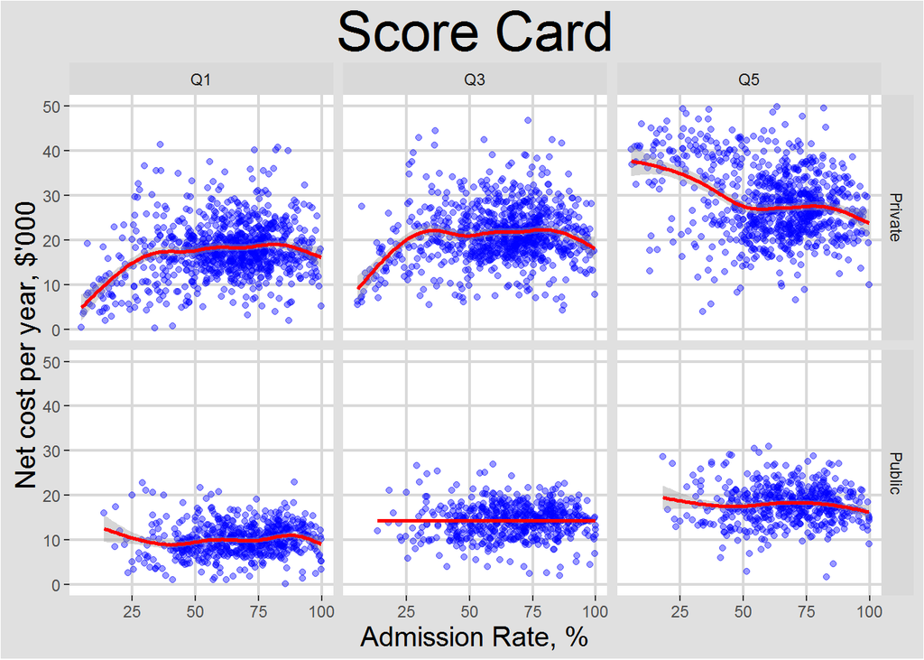

```r
joinedScore_Card %>%
  na.omit() %>%
  ggplot(aes(x = ADM_RATE, y = COST/1000)) +
  geom_point(alpha = .4, color = "blue") +
  geom_smooth(color = "red") +
  facet_grid(CONTROL ~ short_name) +
  ylim(0,50) +
  labs(title = "Score Card", x = "Admission Rate, %", y = "Net cost per year, $'000") +
  theme(
    plot.background = element_rect(fill = "gray88"),
    plot.title = element_text(size = 30),
    axis.title.x = element_text(size = 15),
    axis.title.y = element_text(size = 15),
    panel.grid.minor = element_blank(),
    panel.grid.major = element_line(size = .8, color = "gray85"),
    panel.background = element_rect(fill = "white")
  )
```